# Sebaran Diskrit

Weksi Budiaji

2025-09-17

# Pendahuluan

Sebuah variabel acak diskrit adalah variabel yang hanya dapat mengambil nilai dari suatu himpunan terbatas atau dapat dihitung (countable), misalnya $\{0,1,2,...\}$. Karena nilai yang mungkin muncul dapat dihitung satu per satu, maka untuk menggambarkan peluang dari masing-masing nilai digunakan Fungsi Kepadatan Peluang (Probability Mass Function, PMF).

PMF mendeskripsikan peluang masing-masing nilai yang mungkin diambil variabel acak diskrit. Secara matematis ditulis sebagai:

$P(X=x)$,

dengan dua syarat utama:

- $P(X=x) \geq 0$ untuk semua x (probabilitas tidak pernah negatif).
- $\sum_x P(X=x) = 1$ (jumlah total seluruh probabilitas sama dengan 1).

Contoh: pada lemparan dadu fair,

$P(X=x)=\frac{1}{6}$, $x=1,2,3,4,5,6$

Selain PMF, kita juga dapat menggambarkan distribusi probabilitas dengan Fungsi Distribusi Kumulatif (Cumulative Distribution Function, CDF), yang didefinisikan sebagai:

$F(x) = P(X \leq x) = \sum_{t\leq x} P(X=t)$

artinya CDF pada titik $x$ memberikan total probabilitas bahwa nilai variabel acak $x$ lebih kecil atau sama dengan $x$.

Contoh pada lemparan dadu fair:

$F(3) = P(X \leq 3) = P(1) + P(2) + P(3) = \frac{1}{6} + \frac{1}{6} + \frac{1}{6} = \frac{3}{6} = 0.5$

Momen adalah ukuran ringkas yang menggambarkan karakteristik distribusi. Dua momen utama yang sering dipakai adalah nilai harapan dan varian.

- Nilai harapan: $E[X] = \sum x P(X=x)$, menunjukkan rata-rata teoretis nilai $X$ jika percobaan dilakukan berkali-kali.
- Varian: $Var(X) = E[X^2] - (E[X])^2$, menggambarkan seberapa besar penyebaran nilai $X$ dari rata-ratanya.

Contoh: untuk lemparan dadu fair:

- Nilai harapan:

$E[X] = \sum_{x=1}^6 x \frac{1}{6} = \frac{1+2+3+4+5+6}{6}=3.5$

- Varian:

$E[X^2] = \sum_{x=1}^6 x^2 \frac{1}{6} = \frac{1+4+9+16+25+36}{6}= \frac{91}{6} = 15.17$

$Var (X) = E[X^2] - (E[X])^2 = 15.17-3.5^2= 15.17-12.25=2.92$

## 1. Sebaran Bernoulli

Distribusi Bernoulli memodelkan percobaan dengan dua hasil (biner): sukses (1) dengan probabilitas $p$ dan gagal (0) dengan probabilitas $1-p$. Fungsi kepadatan peluang (PMF) untuk variabel acak $X$ adalah:

$$P(X=1)=p, P(X=0)=1-p, 0\leq p \leq
1$$

Karena hanya dua kemungkinan, PMF sepenuhnya ditentukan oleh satu parameter $p$.

Ekspektasi:

$$E[X] = \sum_{x=0}^{1} x \cdot P(X=x)$$

$$E[X] = 0 \cdot (1-p) + 1 \cdot p = p$$
Varian:

$$Var(X) = E[X^2] - (E[X])^2$$

$$E[X^2] = \sum_{x=0}^{1} x^2 \cdot P(X=x)$$

$$E[X^2] = 0^2 \cdot (1-p) + 1^2 \cdot p$$

$$Var(X) = p - p^2 = p(1-p)$$

varian maksimum terjadi pada $p = 0.5$ (paling tidak pasti), yaitu bernilai $0.25$

Contoh:

- Jika $p=0.5$ (koin fair), maka $E[X] = 0.5$ dan $Var(X) = 0.25$.
- Jika conversion rate sebuah iklan $p=0.1$ (conversion rate 10%), maka Ekspektasi sukses per percobaan $E[X] = 0.10$ dan $Var(X) = 0.1(0.9)=0.09$.

```r
# Probability mass: P(X = x)
p <- 0.3
dbinom(1, size=1, prob=p)   # = p
```

```
## [1] 0.3
```

```r
dbinom(0, size=1, prob=p)   # = 1-p
```

```
## [1] 0.7
```

```r
# Cumulative: P(X <= x)
pbinom(0, size=1, prob=p)   # P(X <= 0) = 1-p
```

```
## [1] 0.7
```

```r
pbinom(1, size=1, prob=p)   # P(X <= 1) = 1
```

```
## [1] 1
```

```r
# Simulasi (generate n Bernoulli trials)
set.seed(2025)
n <- 100
p <- 0.3
x <- rbinom(n, size=1, prob=p)  # vektor 0/1
head(x, n=10)
```

```
##  [1] 1 0 0 0 1 0 1 0 0 0
```

Estimasi (MLE) dan Derivasi Singkat

Untuk $n$ observasi independen dengan $x$ sukses, likelihood dapat dituliskan:

$$L(p) = p^x (1-p)^{n-x}$$

Log-likelihood:

$$\ell(p) = x \ln p + (n-x) \ln (1-p)$$

Turunkan log-likelihood terhadap $p$ dan set sama dengan nol:

$$\frac{d\ell}{dp} = \frac{x}{p} - \frac{n-x}{1-p} = 0 \Rightarrow \hat{p}
= \frac{x}{n}$$

Sehingga didapatkan pendugaan maksimum likelihood (MLE) $\hat{p} = \frac{x}{n}$, jika di R dapat diperoleh dengan $\hat{p} =$`sum(x)/length(x) = mean(x)`.

```r
# Estimasi p (MLE)
p_hat <- mean(x)
p_hat
```

```
## [1] 0.35
```

## 2. Sebaran Binomial

Sebaran Binomial muncul ketika sebuah percobaan Bernoulli dilakukan sebanyak $n$ kali secara independen dan identik, masing-masing dengan probabilitas sukses $p$. Variabel acak $X$ menyatakan jumlah sukses dari $n$ percobaan.

PMF:

$$P(X=k) = \binom{n}{k} p^k (1-p)^{\,n-k}, \qquad k=0,1,\dots,n,\; 0\le p
\le 1$$

Dengan
$$\binom{n}{k} = \frac{n!}{k!(n-k)!}.$$

Ekspektasi:
$$E[X] = \sum_{i=1}^{n} E[X_i] = \sum_{i=1}^{n} p = np$$

Varian:
$$\operatorname{Var}(X) = \sum_{i=1}^{n} \operatorname{Var}(X_i) = np(1-p)$$

Contoh

- Jumlah kepala dari 10 kali lempar koin.
- Jumlah pelanggan yang membeli produk dari 100 orang yang ditawarkan.
- Jumlah siswa yang lulus ujian dari sekelompok siswa.

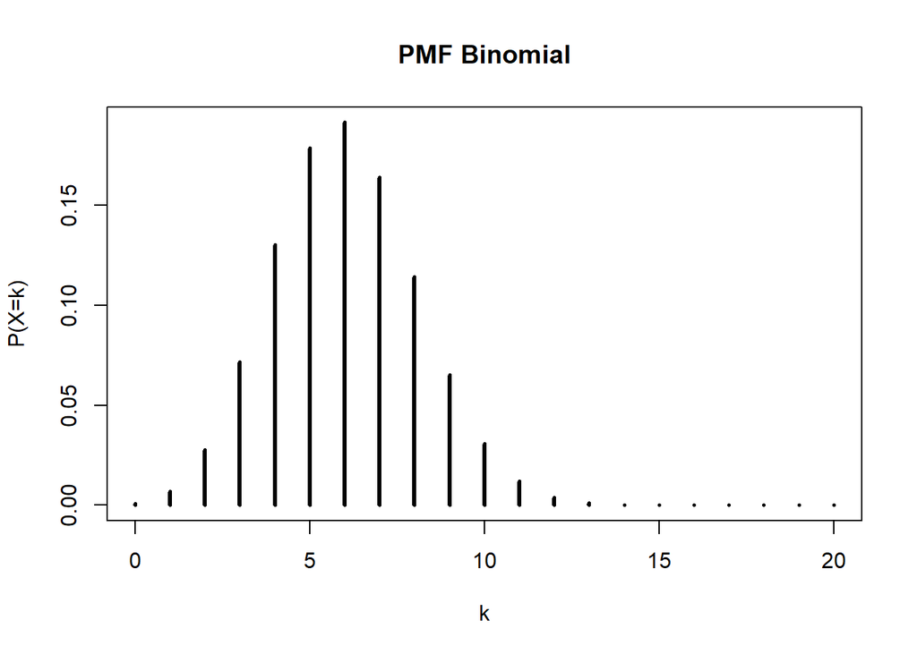

```r
n <- 20; p <- 0.3; x <- 0:n
pmf <- dbinom(x, size=n, prob=p)
cdf <- pbinom(x, size=n, prob=p)
plot(x, pmf, type="h", lwd=3, main="PMF Binomial", xlab="k", ylab="P(X=k)")
```

Estimasi (MLE)

Untuk $n$ percobaan dengan $k$ sukses, fungsi likelihood:

$$L(p) = \binom{n}{k} p^k (1-p)^{\,n-k}$$

Log-likelihood:

$$\ell(p) = ln \binom{n}{k} + k \ln p + (n-k) \ln (1-p)$$

Turunkan log-likelihood terhadap $p$ dan set sama dengan nol:

$$\frac{d\ell}{dp} = \frac{k}{p} - \frac{n-k}{1-p} = 0 \Rightarrow \hat{p}
= \frac{k}{n}$$

Sehingga didapatkan pendugaan maksimum likelihood (MLE) adalah proporsi sukses $\hat{p} = \frac{k}{n}$.

```r
k_obs <- 24     # contoh: 24 sukses dari 100 percobaan
n <- 100
p_hat <- k_obs / n
p_hat
```

```
## [1] 0.24
```

## 3. Sebaran Poisson

Sebaran Poisson digunakan untuk memodelkan jumlah kejadian jarang dalam suatu interval waktu atau ruang, di mana kejadian-kejadian diasumsikan independen dan laju kejadian konstan. Parameter utama adalah $\lambda>0$, yang merepresentasikan rata-rata (ekspektasi) jumlah kejadian per interval.

PMF:

$$\begin{equation}
P(X=k) = e^{-\lambda}\frac{\lambda^k}{k!}, \qquad k=0,1,2,\dots,\;
\lambda>0.
\end{equation}$$

Ekspektasi dan varian:

$$E[X] = \lambda,
\qquad
\operatorname{Var}(X) = \lambda.$$

Artinya ekspektasi dan varian sama-sama bernilai $\lambda$.

contoh:

- Jumlah telepon masuk ke call center dalam 1 jam.
- Jumlah kecelakaan di persimpangan per bulan.
- Jumlah kesalahan cetak pada satu halaman buku.
- Jumlah pengunjung yang melakukan event langka dalam periode tertentu.

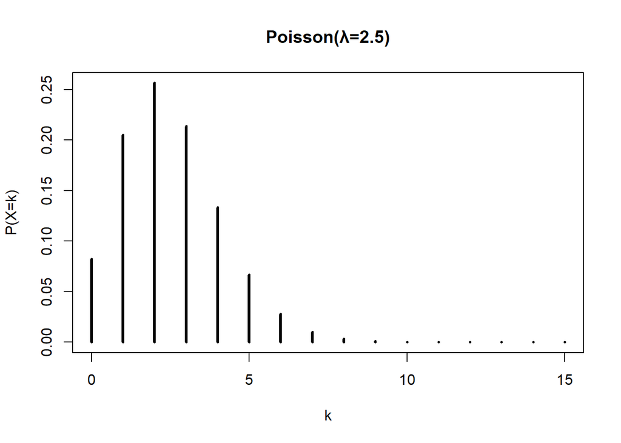

```r
lambda <- 2.5
x <- 0:15
pmf <- dpois(x, lambda)
plot(x, pmf, type='h', lwd=3, main='Poisson(λ=2.5)', xlab='k', ylab='P(X=k)')
```

Estimasi (MLE)

Misalkan kita memiliki $n$ observasi independen $x_1, x_2, \dots, x_n$ dari $\operatorname{Poisson}(\lambda)$. Fungsi likelihood:

$$\begin{equation}
L(\lambda) = \prod_{i=1}^n e^{-\lambda}\frac{\lambda^{x_i}}{x_i!}
= e^{-n\lambda} \lambda^{\sum_{i=1}^n x_i} \prod_{i=1}^n \frac{1}{x_i!}.
\end{equation}$$

Log-likelihood (abaikan konstanta yang tidak tergantung $\lambda$):

$$\begin{equation}
\ell(\lambda) = \ln L(\lambda) = -n\lambda + \left(\sum_{i=1}^n
x_i\right)\ln\lambda + \text{const}.
\end{equation}$$

Turunan terhadap $\lambda$:

$$\begin{equation}
\frac{d\ell}{d\lambda} = -n + \frac{\sum_{i=1}^n x_i}{\lambda}.
\end{equation}$$

Set sama dengan nol untuk mencari titik stasioner:

$$\begin{equation}
-n + \frac{\sum_{i=1}^n x_i}{\hat{\lambda}} = 0
\quad\Rightarrow\quad
\hat{\lambda} = \frac{1}{n}\sum_{i=1}^n x_i = \bar{x}.
\end{equation}$$

Turunan kedua (kurva melengkung ke bawah karena < 0 → titik itu adalah maksimum):

$$\begin{equation}
\frac{d^2\ell}{d\lambda^2} = -\frac{\sum_{i=1}^n x_i}{\lambda^2} < 0,
\end{equation}$$

sehingga $\hat{\lambda}=\bar{x}$ adalah maksimum lokal (MLE). Dengan kata lain, MLE untuk $\lambda$ adalah rata-rata sampel.

```r
samp <- rpois(n, lambda)
lambda_hat <- mean(samp)
lambda_hat
```

```
## [1] 2.6
```

## 4. Sebaran Geometrik

Sebaran Geometrik memodelkan jumlah percobaan sampai sukses pertama pada rangkaian percobaan Bernoulli yang independen dengan probabilitas sukses $p$ (konstan setiap percobaan). Terdapat dua konvensi umum untuk menyatakan variabel acak Geometrik:

1. Definisi (1-based) — $X$ menghitung nomor percobaan di mana sukses pertama terjadi: $X\in{1,2,\dots}$.
   $$\begin{equation}
   P(X=k) = (1-p)^{k-1} p,\qquad k=1,2,\dots,; 0<p\le1.
   \end{equation}$$
2. Definisi (0-based) — $Y$ menghitung jumlah kegagalan sebelum sukses pertama: $Y\in{0,1,2,\dots}$. Hubungannya: $Y=X-1$, dan
   $$\begin{equation}
   P(Y=k)=(1-p)^{k} p,\qquad k=0,1,2,\dots.
   \end{equation}$$

(Perhatikan: di R fungsi `dgeom`/`rgeom` menggunakan definisi 0-based — yaitu mengembalikan jumlah kegagalan sebelum sukses.)

Ekspektasi:

Untuk definisi 1-based ($X$):

$$\begin{equation}
E[X] = \frac{1}{p},
\qquad
\operatorname{Var}(X)=\frac{1-p}{p^2}.
\end{equation}$$

Sifat penting: memoryless. Sebaran Geometrik bersifat memoryless (tanpa memori): $P(X>s+t∣X>s)=P(X>t)$, untuk $s,t\in{0,1,2,\dots}$ (diterjemahkan sesuai definisi yang dipakai). Ini artinya peluang menunggu lebih lama tidak bergantung pada sudah berapa lama kita menunggu. Mengetahui bahwa sampai titik $s$ belum ada sukses artinya kita hanya tahu “sampai sekarang semua $s$ percobaan gagal”. Karena setiap percobaan bersifat independen dan identik, informasi itu tidak mengubah probabilitas sukses pada percobaan-percobaan berikutnya. Jadi setelah $s$ kegagalan, situasinya persis sama seperti memulai dari nol yaitu peluang untuk menunggu lagi $k$ percobaan sampai sukses adalah sama seperti dari awal. Sebaran “terlihat sama” tetapi indeksnya bergeser.

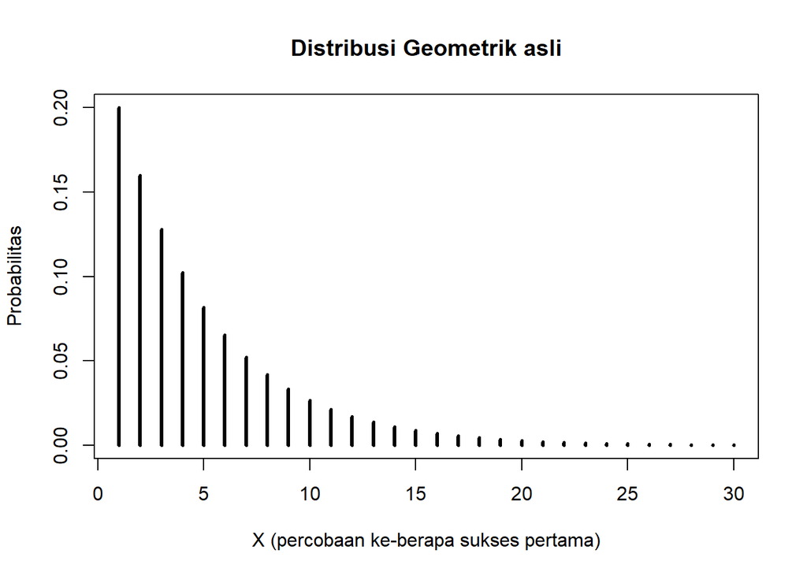

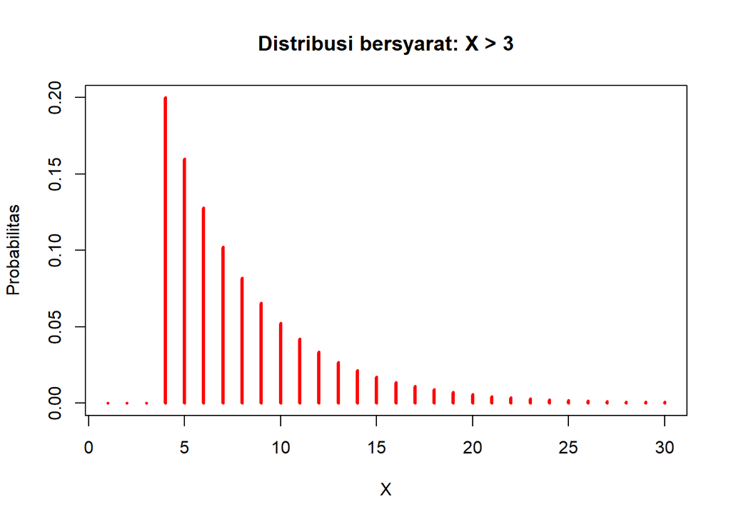

Contoh:

- Jumlah lemparan koin sampai kepala muncul pertama kali.
- Jumlah pasien diperiksa sampai ditemukan yang positif suatu penyakit.
- Jumlah panggilan telepon sampai menemukan pelanggan yang setuju membeli.

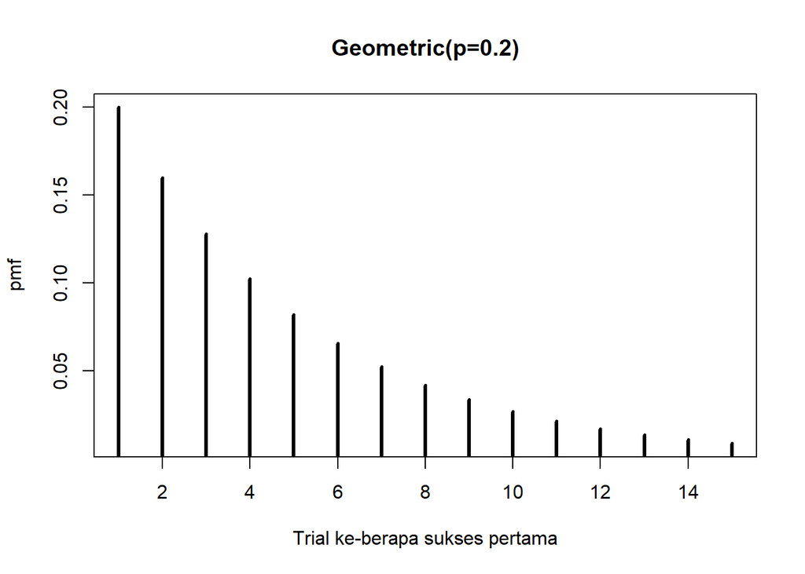

```r
p <- 0.2
x <- 1:15
pmf <- dgeom(x-1, p)
plot(x, pmf, type='h', lwd=3, main='Geometric(p=0.2)', xlab='Trial ke-berapa sukses pertama')
```

Estimasi (MLE)

Misalkan kita mengamati $n$ observasi independen $x_1,\dots,x_n$ menurut definisi 1-based (masing-masing $x_i\in{1,2,\dots}$). Fungsi likelihood:

$$\begin{equation}
L(p) = \prod_{i=1}^n (1-p)^{x_i-1} p
= p^n (1-p)^{\sum_{i=1}^n x_i - n}.
\end{equation}$$

Log-likelihood (abaikan konstanta yang tidak bergantung pada $p$):

$$\begin{equation}
\ell(p) = n\ln p + \left(\sum_{i=1}^n x_i - n\right)\ln(1-p).
\end{equation}$$

Turunan pertama:

$$\begin{equation}
\frac{d\ell}{dp} = \frac{n}{p} - \frac{\sum_{i=1}^n x_i - n}{1-p}.
\end{equation}$$

Set sama dengan nol dan selesaikan untuk $\hat{p}$:

$$\begin{align*}
\frac{n}{\hat{p}} &= \frac{\sum_{i=1}^n x_i - n}{1-\hat{p}} \\
n(1-\hat{p}) &= \hat{p}\left(\sum_{i=1}^n x_i - n\right) \\
n &= \hat{p} \sum_{i=1}^n x_i \\
\hat{p} &= \frac{n}{\sum_{i=1}^n x_i} = \frac{1}{\bar{x}}.
\end{align*}$$

Turunan kedua:

$$\begin{equation}
\frac{d^2\ell}{dp^2} = -\frac{n}{p^2} - \frac{\sum_{i=1}^n x_i -
n}{(1-p)^2} < 0,
\end{equation}$$

sehingga solusi di atas adalah maksimum. Interpretasi sederhana: estimator MLE untuk $p$ adalah kebalikan dari rata-rata sampel waktu sampai sukses pertama $\hat{p}=\frac{1}{\bar{x}}$.

```r
n <- 1000
p
```

```
## [1] 0.2
```

```r
# R menghasilkan jumlah kegagalan sebelum sukses (0-based). Untuk 1-based, tambahkan 1.
samp_failures <- rgeom(n, prob = p)   # 0,1,2,...
samp_1based <- samp_failures + 1      # 1,2,3,...

# Statistik simulasi (harus mendekati teoritis)
mean(samp_1based)      # mendekati 1/p
```

```
## [1] 4.955
```

```r
var(samp_1based)       # mendekati (1-p)/p^2
```

```
## [1] 20.37535
```

```r
p_hat <- 1 / mean(samp_1based)
p_hat
```

```
## [1] 0.2018163
```

## 5. Sebaran Negatif Binomial

Sebaran Negatif Binomial merupakan generalisasi Geometrik yang memodelkan jumlah percobaan sampai diperoleh $r$ sukses. Terdapat dua parametrisasi umum yang perlu dibedakan:

- **Parametrisasi (total percobaan sampai r sukses)**: Variabel acak $X$ adalah jumlah **total percobaan** sampai tercapai $r$-th sukses. Maka $X\in\{r,r+1,\dots\}$.
  $$\begin{equation}
  P(X=k) = \binom{k-1}{r-1} p^{r} (1-p)^{\,k-r}, \qquad k = r,r+1,\dots,
  \; 0<p\le1.
  \end{equation}$$
- **Parametrisasi (jumlah kegagalan sebelum r sukses)**: Variabel acak $Y$ adalah jumlah **kegagalan** sebelum tercapai $r$ sukses. Maka $Y\in\{0,1,2,\dots\}$ dan $Y = X - r$. Bentuk PMF:
  $$\begin{equation}
  P(Y=y) = \binom{y + r - 1}{y} p^{r} (1-p)^{y}, \qquad y = 0,1,2,\dots
  \end{equation}$$

Catatan: di R fungsi `dnbinom`/`rnbinom` menggunakan parametrisasi jumlah kegagalan (`Y`).

Ekspektasi dan varian

Untuk parametrisasi **total percobaan** ($X$):
$$\begin{equation}
E[X] = \frac{r}{p}, \qquad
\operatorname{Var}(X) = \frac{r(1-p)}{p^2}.
\end{equation}$$

Untuk parametrisasi **kegagalan sebelum r sukses** ($Y=X-r$):
$$\begin{equation}
E[Y] = \frac{r(1-p)}{p}, \qquad
\operatorname{Var}(Y) = \frac{r(1-p)}{p^2}.
\end{equation}$$

Perhatikan bahwa kedua varian sama (karena penambahan konstanta tidak mengubah varian).

Contoh:

- Jumlah pertandingan yang harus dimainkan sampai tim meraih 3 kemenangan.
- Jumlah produk yang harus diuji sampai menemukan 5 produk cacat.
- Jumlah panggilan yang dilakukan sampai berhasil mendapatkan $r$ pelanggan yang setuju.

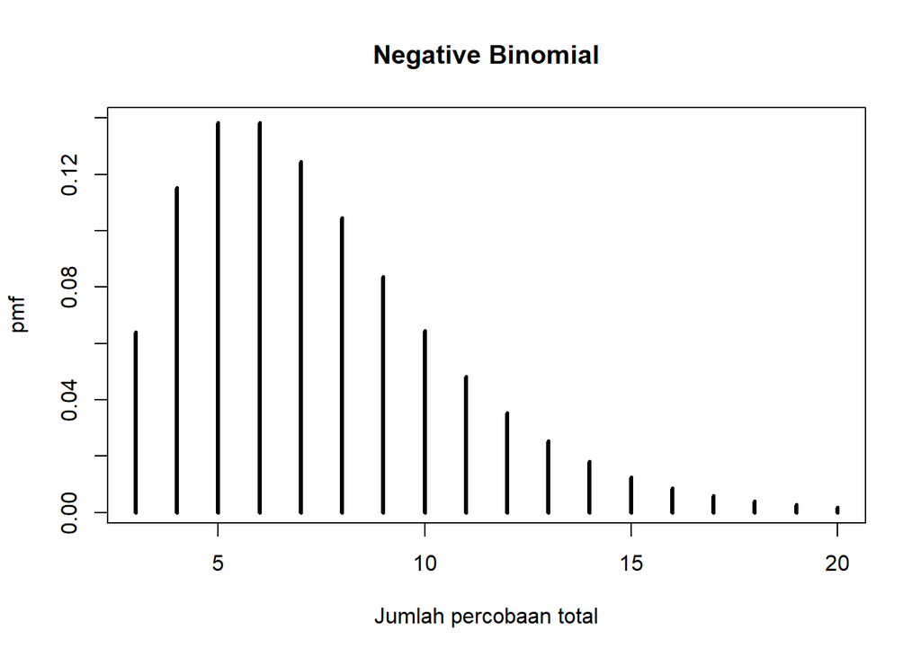

```r
r <- 3; p <- 0.4
x <- r:20
pmf <- dnbinom(x-r, size=r, prob=p)
plot(x, pmf, type='h', lwd=3, main='Negative Binomial', xlab='Jumlah percobaan total')
```

Estimasi (MLE)

Misalkan kita mengamati $n$ observasi total percobaan sampai $r$ sukses: $x_1,x_2,\dots,x_n$ (masing-masing $x_i\ge r$). Fungsi likelihood (mengabaikan konstanta yang tidak bergantung $p$):

$$\begin{equation}
L(p) \propto \prod_{i=1}^n p^{r} (1-p)^{x_i-r}
= p^{rn} (1-p)^{\sum_{i=1}^n (x_i - r)}.
\end{equation}$$

Log-likelihood (tanpa konstanta):

$$\begin{equation}
\ell(p) = rn\ln p + \left(\sum_{i=1}^n x_i - nr\right)\ln(1-p).
\end{equation}$$

Turunan pertama terhadap $p$:

$$\begin{equation}
\frac{d\ell}{dp} = \frac{rn}{p} - \frac{\sum_{i=1}^n x_i - nr}{1-p}.
\end{equation}$$

Set sama dengan nol dan selesaikan untuk $\hat{p}$:

$$\begin{align*}
\frac{rn}{\hat{p}} &= \frac{\sum_{i=1}^n x_i - nr}{1-\hat{p}} \\
rn(1-\hat{p}) &= \hat{p}\left(\sum_{i=1}^n x_i - nr\right) \\
rn &= \hat{p} \sum_{i=1}^n x_i \\
\hat{p} &= \frac{rn}{\sum_{i=1}^n x_i} = \frac{r}{\bar{x}}.
\end{align*}$$

(Periksa khusus: $r=1$ → $\hat p = 1/x$ sama dengan hasil Geometrik.)

Turunan kedua:

$$\begin{equation}
\frac{d^2\ell}{dp^2} = -\frac{rn}{p^2} - \frac{\sum_{i=1}^n x_i -
nr}{(1-p)^2} < 0,
\end{equation}$$

sehingga solusi di atas merupakan maksimum lokal (dan secara praktis global untuk $0<p<1$).

```r
n <- 1000
p
```

```
## [1] 0.4
```

```r
r
```

```
## [1] 3
```

```r
# rnbinom menghasilkan jumlah kegagalan sebelum r sukses (Y)
samp_failures <- rnbinom(n, size = r, prob = p)
samp_total <- samp_failures + r  # X = Y + r

# Hitung MLE p_hat dari sampel 'samp_total'
p_hat <- (r * length(samp_total)) / sum(samp_total)
p_hat
```

```
## [1] 0.3976143
```

## 6. Sebaran Hipergeometrik

Sebaran Hipergeometrik digunakan untuk memodelkan *sampling tanpa pengembalian* dari populasi berhingga. Misalkan populasi berukuran $N$, terdapat $K$ objek yang kita anggap “sukses” (white balls), dan kita mengambil sampel sebanyak $n$ tanpa pengembalian. Variabel acak $X$ menyatakan banyaknya sukses dalam sampel ukuran $n$.

$$\begin{equation}
P(X=k) \;=\; \frac{\displaystyle
\binom{K}{k}\binom{N-K}{\,n-k\,}}{\displaystyle \binom{N}{n}},
\qquad
k = \max(0,\,n+K-N),\,\dots,\,\min(n,K).
\end{equation}$$

Batas bawah $k=\max(0,n+K-N)$ dan batas atas $k=\min(n,K)$ memastikan bilangan kombinasi terdefinisi (tidak negatif).

Ekspektasi dan Varian

$$\begin{equation}
E[X] = n\frac{K}{N}.
\end{equation}$$

$$\begin{equation}
\operatorname{Var}(X) =
n\frac{K}{N}\left(1-\frac{K}{N}\right)\frac{N-n}{\,N-1\,}.
\end{equation}$$

- Faktor $\dfrac{N-n}{N-1}$ disebut *finite population correction (fpc)* yaitu nilai yang menurunkan varian karena sampling tanpa pengembalian.
- Jika sampling dengan pengembalian (aproksimasi besar $N$), fpc mendekati 1 dan Var mendekati Binomial $n p (1-p)$ dengan $p=K/N$.

Contoh:

- Mengambil kartu dari dek (mis. $N=52$, $K=4$ kartu As) tanpa pengembalian.
- Audit dokumen: pilih $n$ dokumen tanpa pengembalian, hitung berapa banyak yang bermasalah.
- Lot quality inspection: jumlah barang cacat dalam sampel tanpa pengembalian dari sepohon produksi.

```r
# Contoh parameter
N <- 50    # ukuran populasi
K <- 10    # jumlah sukses di populasi
n <- 5     # ukuran sampel

# Domain k
k <- seq(from = max(0, n + K - N), to = min(n, K))

# PMF: P(X = k)
pmf <- dhyper(k, m = K, n = N - K, k = n)
data.frame(k = k, P = pmf)
```

```
##   k            P
## 1 0 0.3105627820
## 2 1 0.4313371972
## 3 2 0.2098397176
## 4 3 0.0441767826
## 5 4 0.0039645831
## 6 5 0.0001189375
```

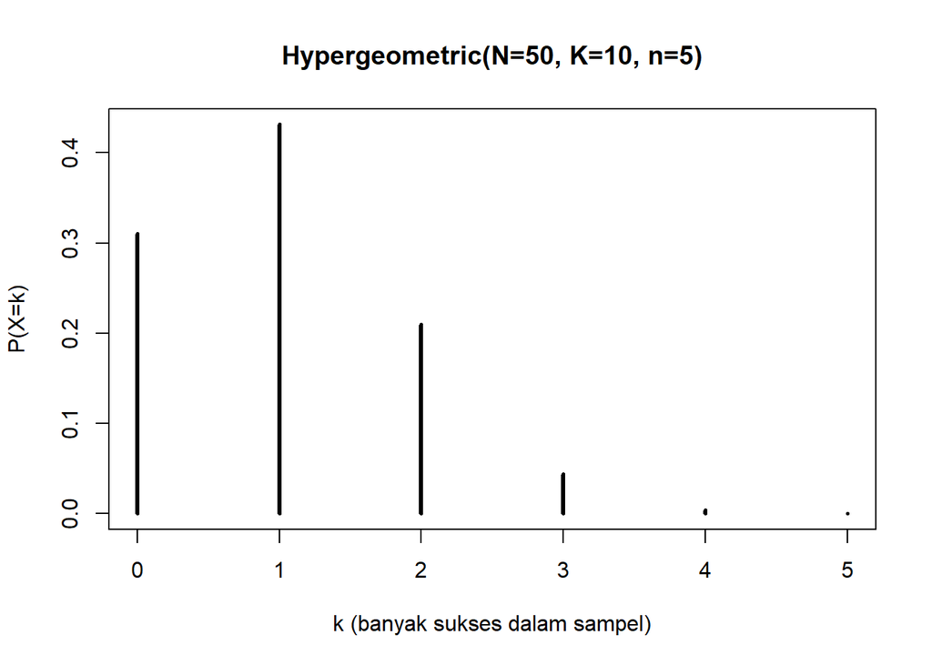

```r
# Plot PMF
plot(k, pmf, type = "h", lwd = 3,
     main = paste0("Hypergeometric(N=",N,", K=",K,", n=",n,")"),
     xlab = "k (banyak sukses dalam sampel)", ylab = "P(X=k)")
```

Estimasi (MLE)

Jika kita hanya punya satu sampel dengan observasi $X=x$, likelihood (sebagai fungsi integer $K$) proporsional terhadap

$$\begin{equation}
L(K) \;\propto\; \displaystyle \binom{K}{x}\binom{N-K}{\,n-x\,},
\qquad
K = 0,1,\dots,\,N.
\end{equation}$$

Karena $K$ harus bilangan bulat, MLE diperoleh dengan mencari $K$ (integer) yang memaksimalkan $L(K)$ (bisa dicari dengan brute force).

Analisis perilaku likelihood Untuk melihat kapan $L(K)$ naik atau turun, perhatikan rasio

$$\begin{equation}
\frac{L(K+1)}{L(K)} \;=\; \frac{\displaystyle
\binom{K+1}{x}\binom{N-K-1}{\,n-x\,}} {\displaystyle
\binom{K}{x}\binom{N-K}{\,n-x\,}} =
\frac{K+1}{K+1-x}.\frac{N-K-n-x}{N-K}
\end{equation}$$

Dengan aljabar sederhana, kondisi $\dfrac{L(K+1)}{L(K)} > 1$ ekuivalen dengan

$$\begin{equation}
nK < (N+1) x - n \Leftrightarrow K < \frac{(N+1)x}{n}-1
\end{equation}$$

Jadi likelihood sebagai fungsi $K$ menaik untuk $K$ di bawah ambang tersebut, lalu menurun setelahnya. Oleh karena itu MLE berada di sekitar nilai ambang itu dan dalam praktiknya MLE akan menjadi salah satu integer di sekitar nilai rasio proporsi $N\cdot(x/n)$ (mis. floor/ceil dari $N x / n$ atau pemeriksaan langsung menggunakan `which.max` pada grid $K=0,\dots,N$).

Catatan:

- Estimator sederhana dan tidak-bulat untuk jumlah sukses di populasi adalah estimator tak-bulat (unbiased):

$E[\tilde K] = \frac{N}{n}x$,

yang memenuhi $E[\tilde K] = K$. Untuk kebutuhan integer $\tilde K$ dapat dibulatkan (mis. ke bawah/ atas atau ke integer terdekat), tetapi MLE (paling benar secara likelihood) sebaiknya dicari dengan pengecekan nilai-nilai integer terdekat.

- Hipergeometrik berbeda dari Binomial karena tanpa pengembalian: percobaan tidak independen.
- Varian berkurang oleh faktor $\dfrac{N-n}{N-1}$; jika $n$ mendekati $N$ varian mengecil drastis.

```r
# Simulasi sampling tanpa pengembalian
m <- 10000
samp <- rhyper(m, m = K, n = N - K, k = n)  # rhyper(nn, m, n, k)
mean(samp)   # harus ≈ n * K / N
```

```
## [1] 1.0012
```

```r
n*K/N
```

```
## [1] 1
```

```r
var(samp)    # harus ≈ teori var
```

```
## [1] 0.7510737
```

```r
n*K/N * (1-K/N) * ((N-n)/(N-1))
```

```
## [1] 0.7346939
```

```r
#MLE
x_obs <- 3  # misal kita mengamati 3 sukses dalam sampel
# Likelihood sebagai fungsi K (K harus integer 0..N)
lik <- sapply(0:N, function(Kc) {
  if ( (x_obs <= min(n, Kc)) && (x_obs >= max(0, n + Kc - N)) ) {
    choose(Kc, x_obs) * choose(N - Kc, n - x_obs)
  } else 0
})
K_candidates <- which(lik == max(lik)) - 1  # -1 karena index R mulai 1
K_candidates
```

```
## [1] 30
```

```r
# Estimator tidak-bulat (unbiased) untuk K
N * x_obs / n
```

```
## [1] 30
```

## 7. Sebaran Multinomial

Sebaran Multinomial merupakan generalisasi dari Binomial untuk lebih dari dua kategori. Misalkan terdapat $k$ kategori dengan probabilitas masing-masing $p_1, p_2, \dots, p_k$ (dengan syarat $\sum_{i=1}^k p_i = 1$). Jika dilakukan $n$ percobaan independen, dan $X_i$ menyatakan banyaknya hasil pada kategori ke-$i$, maka vektor acak $(X_1,\dots,X_k)$ mengikuti distribusi Multinomial. Fungsi kepadatan peluangnya adalah

$$\begin{equation}
P(X_1=x_1, \dots, X_k=x_k)
= \frac{n!}{x_1! \cdots x_k!} \prod_{i=1}^k p_i^{x_i},
\qquad \text{dengan } \sum_{i=1}^k x_i = n.
\end{equation}$$

Ekspektasi dan Varian-Kovarian

Untuk setiap $i=1,\dots,k$:

$$\begin{equation}
E[X_i] = n p_i
\end{equation}$$

$$\begin{equation}
\operatorname{Var}(X_i) = n p_i (1-p_i)
\end{equation}$$

Untuk $i \neq j$:

$$\begin{equation}
\operatorname{Cov}(X_i, X_j) = -n p_i p_j.
\end{equation}$$

Artinya, jumlah kategori saling bergantung karena harus menjumlah ke $n$. Jumlah semua kategori selalu sama dengan $n$, maka $X_i$ tidak bisa benar-benar bebas satu sama lain. Misal pada Survei 100 responden dengan 3 jawaban (setuju, netral, tidak setuju), jika lebih banyak orang menjawab “setuju”, maka otomatis jumlah yang “netral” $+$ “tidak setuju” berkurang (karena total selalu 100).

Hubungannya dengan kovarian negatif karena ada keterikatan ini. Perubahan di satu kategori cenderung diimbangi oleh perubahan lawannya. Jika $X_i$ lebih besar dari ekspektasi, maka kategori lain harus sedikit lebih kecil (agar total tetap $n$). Hasilnya $\operatorname{Cov}(X_i, X_j) = -n p_i p_j < 0$ untuk $i \neq j$, artinya $X_i$ dan $X_j$ punya korelasi negatif.

Contoh:

- Hasil lemparan dadu (6 sisi), dengan $p_i=1/6$ untuk semua sisi.
- Survei opini dengan jawaban lebih dari 2 kategori (misalnya: setuju, netral, tidak setuju).
- Distribusi warna bola dalam toples (misal: merah, biru, hijau).

```r
# Probabilitas tiap kategori
probs <- c(0.2, 0.5, 0.3)   # p1=0.2, p2=0.5, p3=0.3
n <- 10                     # jumlah percobaan
m <- 1000                   # jumlah simulasi

# Simulasi Multinomial
res <- rmultinom(m, size=n, prob=probs)

# Lihat sebagian hasil
res[,1:14]  # 14 sampel pertama (per baris: (x1,x2,x3))
```

```
##      [,1] [,2] [,3] [,4] [,5] [,6] [,7] [,8] [,9] [,10] [,11] [,12] [,13] [,14]
## [1,]    5    4    3    2    2    0    0    0    3     2     2     3     2     5
## [2,]    1    4    4    4    7    7    8    6    4     5     7     4     6     5
## [3,]    4    2    3    4    1    3    2    4    3     3     1     3     2     0
```

```r
# Rata-rata empiris dibandingkan teori
rowMeans(res)     # ≈ n * probs
```

```
## [1] 2.065 4.938 2.997
```

```r
n * probs         # ekspektasi teoretis E(Xi) = n * pi
```

```
## [1] 2 5 3
```

Estimasi (MLE)

Jika data pengamatan adalah $(x_1,\dots,x_k)$ dari total $n$, maka likelihood fungsi terhadap parameter $p_1,\dots,p_k$ adalah:

$$\begin{equation}
L(p_1,\dots,p_k) = \frac{n!}{x_1!\cdots x_k!} \prod_{i=1}^k p_i^{x_i}.
\end{equation}$$

Dengan kendala $\sum_{i=1}^k p_i = 1$, solusi maksimisasi (MLE) adalah:

$$\begin{equation}
\hat p_i = \frac{x_i}{n}, \qquad i=1,\dots,k.
\end{equation}$$

Dengan kata lain, MLE dari probabilitas kategori adalah proporsi frekuensi empiris.

```r
# Estimasi p_i (MLE) dari observasi/ empiris sampel pertama simulasi
x_obs <- res[,1]        # sampel pertama: jumlah tiap kategori (x1,x2,x3)
p_hat <- x_obs / sum(x_obs)
p_hat
```

```
## [1] 0.5 0.1 0.4
```

### Tugas

1. Jika rata-rata pelanggan datang ke toko adalah 3 orang per jam, modelkan dengan Poisson dan hitung $P(X\ge5)$.
2. Dari 100 bola (20 berwarna merah), diambil 10 tanpa pengembalian. Modelkan jumlah bola merah yang diambil dengan distribusi yang tepat.
3. Simulasikan 1.000 percobaan Binomial (n=15, p=0.4) dan bandingkan histogram hasil simulasi dengan PMF teoretis.